scTyper: a comprehensive pipeline for the cell typing analysis of single-cell RNA-seq data —————————————————————————————————————

# 1 Data preparations

scTyper requires three types of input data: single-cell RNA-seq (scRNA-seq) data, phenotype data and cell type markers.

## 1.1 scRNA-seq data

```r
# load test scRNA-seq dataset
library(scTyper)
test.seurat=loadTestData()
```

scTyper can also use the ‘Seurat’ object for raw read counts data as input by setting the parameter ‘norm.seuart’ to ‘TRUE’. For user’s convenience, scTyper also supports with raw data preprocessing pipelines for FASTQC and Cell Ranger from 10X Genomics by setting the parameters ‘qc’, ‘run.cellranger’ and ‘norm.seurat’ to ‘TRUE’. The preprocessing includes quality control, sequence alignment and quantification of raw sequencing data. See below for details.

## 1.2 Phenotype data

scTyper requires a file in the form of ‘CSV’ that contains the information of sample ID and tissue type for the malignant cell typing. This file should be named Sample_ID in the first column and TissueType in the second column (Refer to the example data below).

| Sample_ID | TissueType |
| --- | --- |
| sample_1 | Cancer |
| sample_2 | Cancer |
| sample_3 | Normal |
| sample_4 | Normal |
| sample_5 | Normal |

**Phenotype data for test dataset**

| Sample_ID | TissueType |
| --- | --- |
| Cancer_P0 | Cancer |
| LymphNode_P0 | Lymphnode |
| Cancer_P5 | Cancer |
| LymphNode_P5 | Lymphnode |
| Cancer_P6 | Cancer |
| Cancer_P7 | Cancer |
| Cancer_P8 | Cancer |
| Cancer_P10 | Cancer |
| Cancer_P12 | Cancer |
| Cancer_P13 | Cancer |
| Cancer_P16 | Cancer |
| Cancer_P17 | Cancer |
| Cancer_P18 | Cancer |
| Cancer_P20 | Cancer |
| LymphNode_P20 | Lymphnode |
| Cancer_P22 | Cancer |
| Cancer_P23 | Cancer |
| Cancer_P24 | Cancer |
| Cancer_P25 | Cancer |
| LymphNode_P25 | Lymphnode |
| Cancer_P26 | Cancer |
| LymphNode_P26 | Lymphnode |
| Cancer_P28 | Cancer |
| LymphNode_P28 | Lymphnode |

```r
# phenotype data for test data
pheno.fn=system.file("extdata/pheno_info_public.csv", package = "scTyper")
```

## 1.3 Marker selection

The scTyper package provides manually curated and pre-installed cell marker databases comprised of ‘scTyper.db’ and ‘CellMarker DB’ for cell typing. We have used a unified nomenclature to label the marker gene sets in [the database](https://github.com/omicsCore/scTyper/files/4723417/cell.marker.database.xlsx). For example, a cell marker label ‘Puram.2017.HNSCC.TME’ was designated by concatenating the first author name of the publication (‘Puram’), publication year (‘2017’), tissue type/cancer type (‘HNSCC’), and categories of cell composition (‘TME’, tumor microenvironment). Detailed information about the cell markers such as data source, PubMed ID, species, tissue type, study detail, etc. was also provided in the ‘extdata’ directory ([scTyper.db](https://github.com/omicsCore/scTyper/blob/master/inst/extdata/sigTyper.txt), [CellMarker DB file](https://github.com/omicsCore/scTyper/blob/master/inst/extdata/CellMarker.DB.txt)).  
Using this nomenclature, users can easily search the cell markers of interest.  
If the user wants to set cell markers for one or more studies, set the desired study names of ‘StudyName’ column as a ‘marker’ parameter.  
Following is examples:

```r
# single study
marker="Puram.2017.HNSCC.TME"
```

```r
# multiple study
marker=c("Kawai.2018.Liver", "Li.2017.CRC.TME")
```

Users can also set cell markers by combining identifiers of interest. Following is examples:

```r
# Identifier
marker=c("Costea.2013.OSCC.CAF:Normal cell:NF", "Costea.2013.OSCC.CAF:Cancer cell:CAF_D",
         "Elyada.2019.PDAC.CAF:Cancer cell:iCAF", "Elyada.2019.PDAC.CAF:Cancer cell:myCAF")
```

Also, scTyper allows a ‘list’ data type for user-defined cell markers.  
Following is examples:

```r
# user defined marker list
marker=list(T_cell=c("CD2", "CD3D", "CD3E", "CD3G"),
            Fibroblast=c("FAP", "PDPN", "COL1A2", "DCN", "COL3A1", "COL6A1"),
            Macrophage=c("CD14", "CD163", "CD68", "FCGR2A", "CSF1R"),
            Dendritic_cell=c("CD40", "CD80", "CD83", "CCR7"),
            Mast_cell=c("CMA1", "MS4A2", "TPSAB1", "TPSB2"),
            Myocyte=c("ACTA1", "ACTN2", "MYL2", "MYH2"),
            Endothelial.cell=c("PECAM1", "VWF", "ENG"),
            B_Plasma_cell=c("SLAMF7", "CD79A", "BLNK", "FCRL5"),
            Epithelial_cell=c("KRT14", "KRT17", "KRT6A", "KRT5", "KRT19", "KRT8",
                              "KRT16", "KRT18", "KRT6B", "KRT15", "KRT6C", "KRTCAP3","EPCAM", "SFN"))
```

Note that if there are overlapping genes between markers of each cell type, those genes are excluded from cell typing. And if there is only one marker gene for a particular cell type, scTyper generates error message (`"### Error :: If there is only one marker gene for a particular cell type, please use the average method ###`). In this case, users can run scTyper by setting the parameter ‘cell.type.method’ to ‘Average’.

### 1.3.1 Modification of the marker database (Optional)

If you want to modify marker database, you can change the ‘sigTyper.db.txt’ file in the ‘scTyper/extdata’ directory and then use the “update.sig.db()” function to modify the original marker database.

```r
update.sig.db(sig.db.path = system.file(sig.db.path="extdata/sigTyper.DB.txt", package = "scTyper"), db.name=c("sigTyper.db"), output.dir=system.file("/data",package = "scTyper"))
```

# 2 Run scTyper()

scTyper consist of the modularized processes of ‘QC’, ‘Cell Ranger’, ‘Seurat processing’, ‘cell typing’, and ‘malignant cell typing’. Pre-processing step includes QC, Cell Ranger, Seurat processing. Cell typing algorithms are implemented to estimate the expression of cell marker sets, including NTP (Nearest template prediction), ES (pre-ranked GSEA), and Average (average expression values). Also in malignant cell typing, inferred DNA copy numbers are estimated by an inferCNV R package. These processes can be customized by manipulating the parameters for each process. scTyper can be run as a single command, as in the following example.

- *Skip pre-processing and run NTP cell typing with inferCNV at cell level*

```r
celltyped.seurat=scTyper(seurat.object=test.seurat,
                         marker="Puram.2017.HNSCC.TME",
                         wd = getwd(),
                         output.name = "scTyper.output",
                         pheno.fn = pheno.fn,
                         qc = FALSE,
                         run.cellranger=FALSE,
                         norm.seurat=FALSE,
                         cell.typing.method="NTP",
                         level="cell",
                         run.inferCNV=TRUE,
                         proj.name = "scTyper",
                         gene.ref.gtf="/data/pubdata/ngs_ref/cellranger/refdata-cellranger-GRCh38-1.2.0/genes/genes.gtf",
                         feature.to.test = "tissue.type",
                         cells.test_excluded=c("Epithelial_cell", "Unresolved_cell"),
                         cells.test_reference = "Normal",
                         malignant.cell.type="Epithelial_cell",
                         report.mode=TRUE,
                         mc.cores = 1)
```

# 3 scTyper() arguments

In the table below, the user can check the argument and description of scTyper(). For a detailed parameter description of the single command and its internal step-by-step functions, see the [Reference Manual](https://github.com/omicsCore/scTyper/files/4928754/Reference_manual.pdf). Note when the user have pre-processed seurat object (completed with qc, Cell Ranger and Seurat processing), seurat.object parameter must be assigned.

| Process | Parameters | Description | Values |
| --- | --- | --- | --- |
| global configuration | wd | Working directory | Character |
|  | output.name | Output directory name | Character |
|  | pheno.fn | Phenotype file path | File path |
|  | qc, run.cellranger , norm.seurat | Indicate whether the process run | Logical (Default = ‘FALSE’) |
|  | cell.typing.method | Cell typing method | ‘NTP’ (Default), ‘ES’, ‘Average’ |
|  | level | Indicate the cell assignment level (cell or cluster) | ‘cell’ (Default), ‘cluster’ |
|  | run.inferCNV | Indicate whether ‘malignant cell typing by inferCNV process run | Logical (Default = ‘TRUE’) |
|  | project.name | Project name | Character |
|  | mc.cores | Number of cores | Numeric (Default = ‘1’) |
|  | report.mode | Generate report file | Logical (Default = ‘TRUE’) |
| QC | fastqc.path | FastQC program path | File path |
|  | fastq.dir | FastQC output directory | File path |
|  | fq1.idx | Index of the FASTQ file (Read 1) | Character (Default = ‘_R1_001.fastq’) |
|  | fq2.idx | Index of the FASTQ file (Read 2) | Character (Default = ‘_R2_001.fastq’) |
| CellRanger | cellranger.path | Cell Ranger program path | File path |
|  | cellranger.ref.dir | Directory of Cell Ranger reference file | File path |
| Seurat processing | percent.min.cells | Cutoff to filter features containing minimum percent of cells | 0.1 |
|  | min.features | Cutoff to filter cells containing minimum number of features | 200 |
|  | percent.mt | Cutoff for filtering cells that have >n percent mitochondrial counts | 10 |
|  | vars.to.regress | Variables to regress out | Default=c(‘nCount_RNA’, ‘percent.mt’) |
|  | dims | A vector of the dimensions to use in construction of the SNN graph. | 1:100 |
|  | resolution | Value of the resolution parameter, use a value above (below) 1.0 if you want to obtain a larger (smaller) number of communities. | 2 |
| Cell typing | seurat.object | Seurat object | Seurat object |
|  | slot | Data type of Seurat object | ‘scale.data’ (Default), ‘count.data’, ‘data’ |
|  | marker | Cell markers to use cell typing | Character or List (Signature names or Study names or User defined gene set list) |
|  | assay | Assay of Seurat object | Character (Default=’RNA’) |
|  | NTP.g.filter.method | Method to filter genes in NTP | ‘sd’ (Default),’mad’, ‘none’ |
|  | NTP.gene.filter.cutoff | Cutoff to filter genes of in NTP | Numeric (Default = ‘0.3’) |
|  | NTP.distance | NTP distance method | ‘cosine’ (Default), ‘correlation’ |
|  | NTP.norm.method | NTP normalization method | ‘none’ (Default), ‘row.std’ |
| Malignant cell typing (inferCNV | gene.ref.gtf | Path of GTF file including genomic location for genes | File path |
|  | feature.to.test | Column header name of the meta data in Seurat object (select the cell groups for T.test) | Character (Default = ‘cell.type’), ‘tissue.type’ |
|  | cells.test_excluded | A value indicates the cells to be excluded in T.test | Character (Default = ‘Epithelial’) |
|  | cells.test_reference | A value indicates the cells to use as be excluded in T.test | Character (Default = ‘immune’) |
|  | fc.cutoff | Cutoff of fold change | Numeric (Default = ‘0.05’) |
|  | cutoff.gene.cluster | A cutoff P-value for filtering out the gene clusters (calculated from GO analysis) | Numeric (Default = ‘0.05’) |
|  | malignant.cell.type | Cell type to assign malignant cell | Character (Default = ’Epithelial’) |

## 3.1 **inferCNV** parameter in scTyper()

InferCNV is an analysis method that infer CNVs (copy number variations) from single-cell RNA-seq data.  
See the parameters below for gene cluster detection in inferCNV.

**feature.to.test** : Cell group for permutation t.test in the inferCNV process. The value is “tissue.type” or “cell.type”, the column header name of the metadata in the Seurat object.  
**cells.test_excluded** Cell type to be excluded in permutation t.test from the inferCNV process.  
**cells.test_reference** Cell type containing the classification of the reference cell in permutation t.test from the inferCNV process.

# 4 scTyper() final output

- **Seurat object** : scTyper() function returns a Seurat object, which is a widely used data type for the subsequent analysis and biological interpretation of scRNA-seq. The seurat object is a class allowing for the storage and manipulation of single-cell data. The seurat object includes any piece of information associated with a cell (examples include read depth, alignment rate, experimental batch, or subpopulation identity) or feature (ENSG name, variance). After scTyper process, the seurat object includes the inferred cell type and cnv core as a result of cell typing.

The following is a metadata column that stores pipeline results in seurat object.  
- cell.type: Inferred cell type results  
- cnv.score: Copy number variation score estimated by malignant cell typing (inferCNV)  
- malignant.st: Logical value of malignant cells estimated by malignant cell typing (inferCNV)

- **Report file** : If report.mode=TRUE in scTyper() parameter, the results and the executed processes are automatically documented as a report. ‘report.mode’ is a parameter used to combine the results into one unified file. The report summarizes the processing steps, cell typing and clustering results, and visualizing the results plots. This may help users reproduce their analysis workflows.
- **Automatically generated output directory** : The result files are automatically created in the output directory set by the user with the parameter ‘wd’ and ‘output.name’ depending on the processing step.

  - 00_qc : FastQC output directory  
  - 01_count : CellRanger output directory  
  - 02_NTP : NTP output directory  
  - 03_inferCNV : inferCNV output directory  
  - data : RData directory (rda). The final result, ‘seurat.rda’, is saved.

# 5 Visualization

If **“report.mode = TRUE”** in scTyper (), visualization is performed automatically. The following shows the individual visualization using the final output seurat object.

- **Cell type statistics across samples**  
  Number of cells by cell type per sample

```r
cell.type.tbl=table(celltyped.seurat$cell.type)
ct.sample.tbl=table(celltyped.seurat$cell.type, celltyped.seurat$sample.name)

celltype.stat=cbind(cell.type.tbl, ct.sample.tbl)
colnames(celltype.stat)[1]="Total"
kable(celltype.stat) %>%
  kable_styling(bootstrap_options = "striped", full_width = F, position = "left")
```

|  | Total | Cancer_P0 | Cancer_P10 | Cancer_P12 | Cancer_P13 | Cancer_P16 | Cancer_P17 | Cancer_P18 | Cancer_P20 | Cancer_P22 | Cancer_P23 | Cancer_P24 | Cancer_P25 | Cancer_P26 | Cancer_P28 | Cancer_P5 | Cancer_P6 | Cancer_P7 | Cancer_P8 | LymphNode_P0 | LymphNode_P20 | LymphNode_P25 | LymphNode_P26 | LymphNode_P28 | LymphNode_P5 |
| --- | --- | --- | --- | --- | --- | --- | --- | --- | --- | --- | --- | --- | --- | --- | --- | --- | --- | --- | --- | --- | --- | --- | --- | --- | --- |
| B_Plasma_cell | 199 | 5 | 44 | 2 | 10 | 15 | 6 | 21 | 0 | 0 | 0 | 0 | 6 | 0 | 0 | 3 | 4 | 0 | 13 | 13 | 1 | 27 | 3 | 23 | 3 |
| Dendritic_cell | 281 | 19 | 5 | 13 | 36 | 29 | 10 | 36 | 2 | 5 | 0 | 3 | 35 | 5 | 27 | 7 | 2 | 0 | 10 | 1 | 0 | 22 | 5 | 7 | 2 |
| Endothelial_cell | 303 | 3 | 7 | 0 | 3 | 40 | 18 | 20 | 2 | 2 | 0 | 3 | 10 | 5 | 27 | 10 | 42 | 0 | 26 | 1 | 0 | 20 | 14 | 20 | 30 |
| Fibroblast | 798 | 13 | 24 | 0 | 5 | 77 | 39 | 30 | 11 | 39 | 0 | 61 | 66 | 43 | 152 | 15 | 39 | 1 | 19 | 4 | 0 | 41 | 44 | 62 | 13 |
| Macrophage | 163 | 4 | 1 | 2 | 4 | 17 | 2 | 31 | 2 | 0 | 0 | 5 | 8 | 3 | 20 | 41 | 3 | 0 | 3 | 0 | 0 | 8 | 2 | 6 | 1 |
| Malignant_cell | 2761 | 20 | 4 | 14 | 16 | 101 | 356 | 230 | 328 | 123 | 0 | 30 | 194 | 63 | 78 | 108 | 213 | 6 | 12 | 0 | 345 | 91 | 218 | 112 | 99 |
| Mast_cell | 135 | 7 | 1 | 1 | 4 | 25 | 8 | 14 | 0 | 23 | 0 | 21 | 13 | 1 | 0 | 4 | 1 | 0 | 3 | 2 | 0 | 3 | 0 | 2 | 2 |
| Myocyte | 233 | 4 | 3 | 1 | 2 | 18 | 3 | 19 | 0 | 9 | 0 | 7 | 35 | 7 | 66 | 1 | 4 | 0 | 0 | 1 | 0 | 21 | 11 | 14 | 7 |
| T_cell | 1029 | 184 | 0 | 124 | 10 | 274 | 48 | 166 | 0 | 0 | 51 | 0 | 67 | 3 | 0 | 24 | 0 | 0 | 18 | 1 | 0 | 58 | 1 | 0 | 0 |

- **Distribution of inferred cell types**  
  The bar plot shows the cell type distribution of the sample.

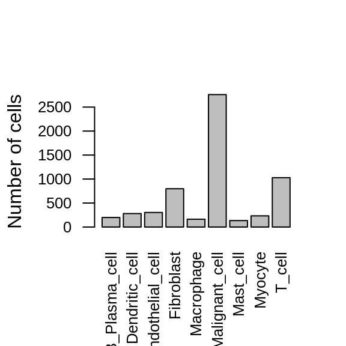

```r
barplot(cell.type.tbl, las=2, ylab="Number of cells", cex.names=0.8, cex.axis=0.8)
```

- **Proportion of cell types across samples**  
  The bar plot shows the cell type proportion of the sample.

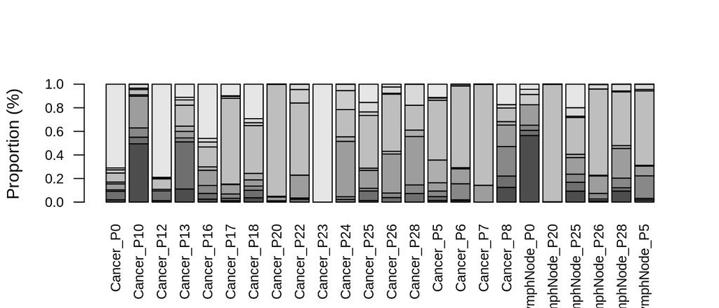

```r
ct.sample.proportion=apply(ct.sample.tbl, 2, function(a) a/sum(a))
barplot(ct.sample.proportion, las=2, ylab="Proportion (%)", cex.names=0.8, cex.axis=0.8, legend.text = rownames(ct.sample.proportion), args.legend = list(x = 'right', bty='n', inset=c(-0.3,0), xpd = TRUE, cex=0.7))
```

- **inferred cell types by cell typing method**  
  The t-SNE plot with colors representing inferred cell type label.

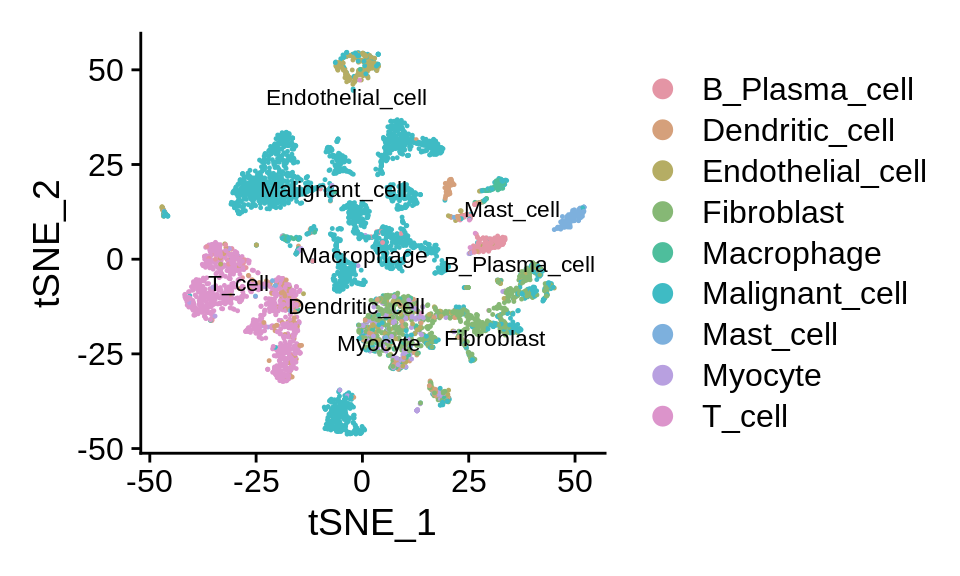

```r
cols=rainbow_hcl(length(levels(celltyped.seurat$cell.type))); names(cols)=levels(celltyped.seurat$cell.type)
p1=DimPlot(celltyped.seurat, reduction = 'tsne',group.by="cell.type",label=F,cols=cols, pt.size=0.2); p1=LabelClusters(plot = p1, id = "cell.type", size = 3)
p1
```

- **Malignant cells by inferCNV**  
  The t-SNE plot shows malignant cells estimated with inferCNV.

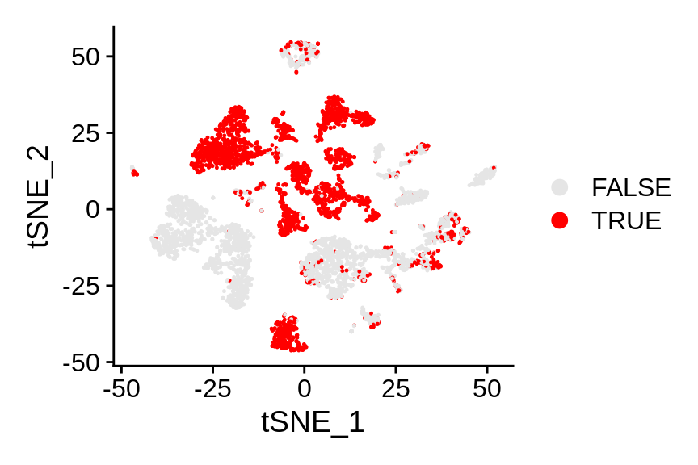

```r
p4=DimPlot(celltyped.seurat, reduction = 'tsne',group.by="malignant.st",label=F, pt.size=0.2, cols=c("grey90", "red"))
p4
```

- **CNV score by inferCNV**  
  The t-SNE plot shows the proportion of CNV scores assigned by using the inferCNV algorithm.

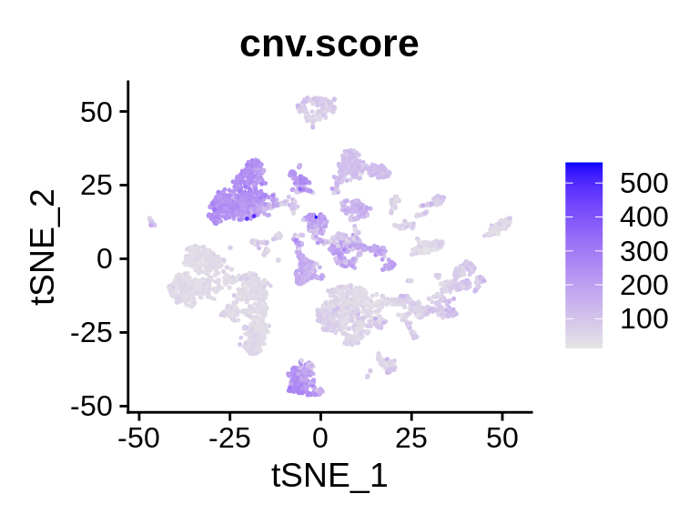

```r
p5=FeaturePlot(celltyped.seurat, features = "cnv.score", cols=c("grey90", "blue"), label=FALSE, pt.size=0.2)
p5
```

- **Seurat clusters**  
  The t-SNE plot shows the distribution of cluster classified by Seurat.

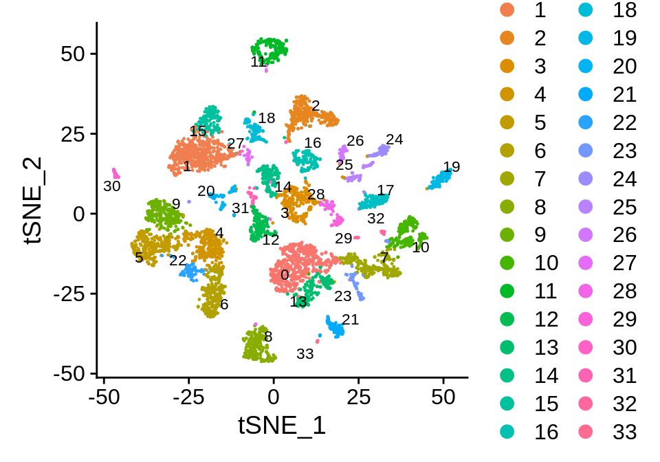

```r
p2=DimPlot(celltyped.seurat, reduction = 'tsne',group.by="seurat_clusters",label=F, pt.size=0.2); p2=LabelClusters(plot = p2, id = "seurat_clusters", size = 3)
p2
```

- **Samples**  
  The t-SNE plot shows the distribution of sample.

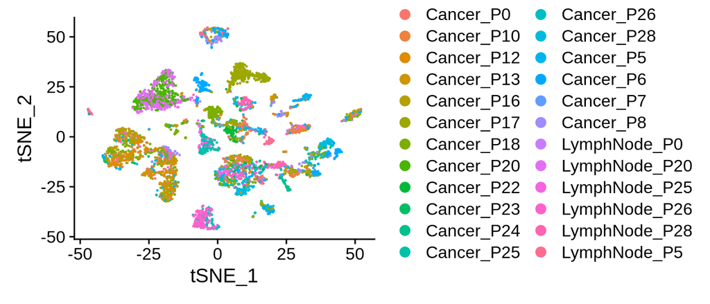

```r
p3=DimPlot(celltyped.seurat, reduction = 'tsne',group.by="sample.name",label=F, pt.size=0.2)
p3
```

- **Cell markers heatmap**  
  The heatmap shows the cell typing result and the gene expression levels of cell marker gene sets from Puram.2017.HNSCC.TME. The cell type assigned for each method is indicated by a color bar.

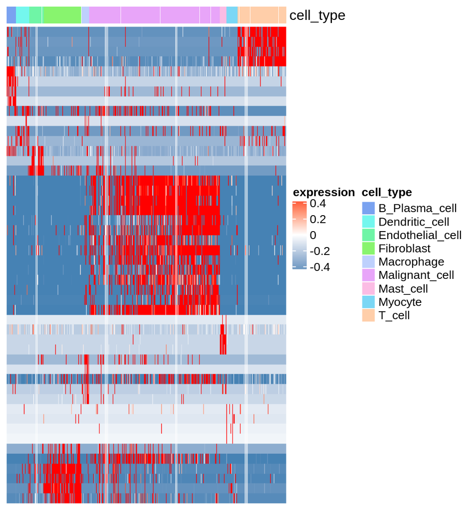

```r
draw.heatmap(seurat = celltyped.seurat,
             wd = "/data/Rpackage/scTyper",
             run.inferCNV = TRUE,
             slot = "scale.data",
             marker="Puram.2017.HNSCC.TME")
```

# 6 Example

- *Skip pre-processing and run ES cell typing using inferCNV at cell level*  
  If the user wants to use “ES” cell typing method and run inferCNV at cell level, see the following parameters.

```r
celltyped.seurat=scTyper(seurat.object=test.seurat,
                         marker="Puram.2017.HNSCC.TME",
                         wd = getwd(),
                         output.name = "scTyper.output",
                         pheno.fn = pheno.fn,
                         qc = FALSE,
                         run.cellranger=FALSE,
                         norm.seurat=FALSE,
                         cell.typing.method="ES",
                         level="cell",
                         run.inferCNV=TRUE,
                         proj.name = "scTyper",
                         gene.ref.gtf="/data/pubdata/ngs_ref/cellranger/refdata-cellranger-GRCh38-1.2.0/genes/genes.gtf",
                         feature.to.test = "tissue.type",
                         cells.test_excluded=c("Epithelial_cell", "Unresolved_cell"),
                         cells.test_reference = "Normal",
                         malignant.cell.type="Epithelial_cell",
                         report.mode=TRUE,
                         mc.cores = 1)
```

- *Run pre-processing (QC, CellRanger, Normalization) and NTP cell typing with inferCNV at cell level*  
  If users want to run all pipelines with NTP cell typing method at cell level, see the following parameters.

```r
###### Running all step (User's data)
processed.celltyped.seurat=scTyper(marker="Puram.2017.HNSCC.TME",
                                   wd="/data/Rpackage/scTyper",
                                   output.name = "test.result",
                                   pheno.fn="/data/Rpackage/scTyper/data/pheno_info_test.csv",
                                   qc = TRUE,
                                   run.cellranger=TRUE,
                                   norm.seurat=TRUE,
                                   cell.typing.method="NTP",
                                   level="cell",
                                   run.inferCNV=TRUE,
                                   proj.name = "scTyper",
                                   fastqc.path="/data/program/bin/fastqc",
                                   fastq.dir="/data/Rpackage/scTyper/test",
                                   fq1.idx="_R1_001.fastq",
                                   fq2.idx="_R2_001.fastq",
                                   cellranger.path="/data/program/bin/cellranger",
                                   cellranger.ref.dir="/data/pubdata/ngs_ref/cellranger/refdata-cellranger-GRCh38-1.2.0",
                                   gene.ref.gtf="/data/pubdata/ngs_ref/cellranger/refdata-cellranger-GRCh38-1.2.0/genes/genes.gtf",
                                   feature.to.test = "tissue.type",
                                   cells.test_excluded=c("Epithelial_cell", "Unresolved_cell"),
                                   cells.test_reference = "Normal",
                                   malignant.cell.type="Epithelial_cell",
                                   report.mode=TRUE,
                                   mc.cores = 1)
```

Help information is available with scTyper –help.